# 8th assignment

Bastien Cadiou

2022-04-16

# The data

Once again, we use the uscomp dataset.

```r
data(uscomp)
str(uscomp)
```

```
## 'data.frame':    79 obs. of  7 variables:
##  $ Assets      : int  19788 5074 13621 1117 1633 5651 5835 3494 1654 1679 ...
##  $ Sales       : Factor w/ 79 levels "1037","1038",..: 78 32 55 2 71 6 48 18 52 10 ...
##  $ Market Value: int  10636 1892 4572 478 679 2002 1601 1442 779 687 ...
##  $ Profits     : num  1092.9 239.9 485 59.7 74.3 ...
##  $ Cash Flow   : num  2576.8 578.3 898.9 91.7 135.9 ...
##  $ Employees   : num  79.4 21.9 23.4 3.8 2.8 6.2 10.8 6.4 1.6 4.6 ...
##  $ Sector      : Factor w/ 9 levels "Communication",..: 1 1 2 2 2 2 2 2 2 2 ...
```

```r
#uscomp$Sales <- as.integer(uscomp$Sales)
```

On our previous PCA, we transformed the “Sales” variable into numerical. However, by inspecting the data, we realized that was not a good idea and even if we do not have clear explanations about this variable, we will let it be factorial.

## Empirical correlations

Let’s use the corrplot library to visualize the correlations between covariates.

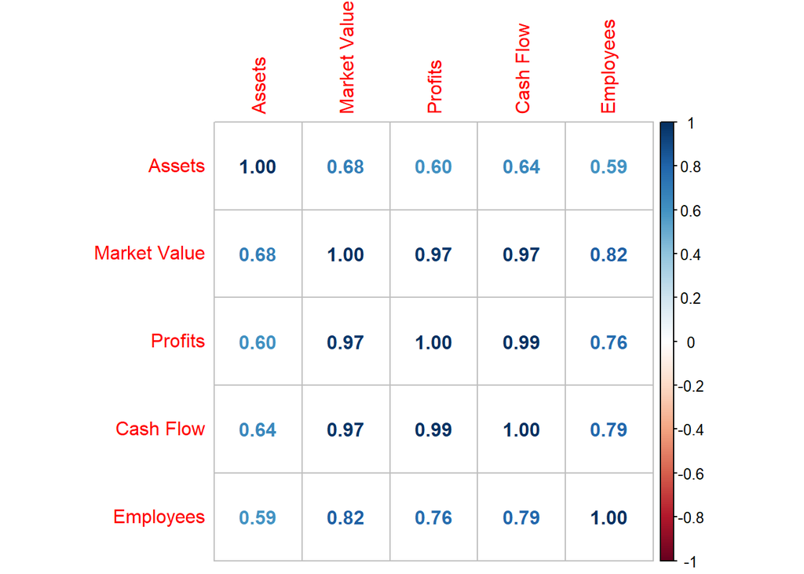

```r
corrplot(cor(uscomp[,c(1,3,4,5,6)]), method = "number")
```

Once again, they are all positively correlated. Furthermore, we notice that Market Value, Profits and Cash Flow are highly correlated, with a coefficient near to one.

# Factor Analysis

```r
fa_1 <- factanal(uscomp[,c(1,3,4,5,6)], factors = 2, rotation = "varimax")
print(fa_1, digits=2, cutoff=.6, sort=TRUE)
```

```
##
## Call:
## factanal(x = uscomp[, c(1, 3, 4, 5, 6)], factors = 2, rotation = "varimax")
##
## Uniquenesses:
##       Assets Market Value      Profits    Cash Flow    Employees
##         0.40         0.02         0.00         0.01         0.28
##
## Loadings:
##              Factor1 Factor2
## Market Value 0.79
## Profits      0.90
## Cash Flow    0.87
## Assets               0.70
## Employees            0.67
##
##                Factor1 Factor2
## SS loadings       2.58    1.70
## Proportion Var    0.52    0.34
## Cumulative Var    0.52    0.86
##
## Test of the hypothesis that 2 factors are sufficient.
## The chi square statistic is 7.13 on 1 degree of freedom.
## The p-value is 0.00757
```

```r
fa_2 <- factanal(uscomp[,c(1,3,4,5,6)], factors = 1, rotation = "varimax")
print(fa_2, digits=2, cutoff=.6, sort=TRUE)
```

```
##
## Call:
## factanal(x = uscomp[, c(1, 3, 4, 5, 6)], factors = 1, rotation = "varimax")
##
## Uniquenesses:
##       Assets Market Value      Profits    Cash Flow    Employees
##         0.59         0.05         0.02         0.01         0.38
##
## Loadings:
## [1] 0.64 0.98 0.99 1.00 0.79
##
##                Factor1
## SS loadings       3.96
## Proportion Var    0.79
##
## Test of the hypothesis that 1 factor is sufficient.
## The chi square statistic is 39.27 on 5 degrees of freedom.
## The p-value is 2.09e-07
```

## Graphical outputs

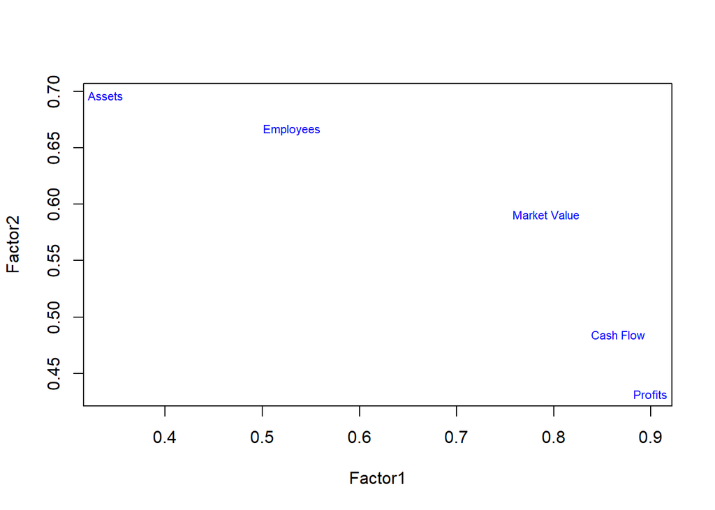

```r
par(mfrow=c(1,1))
loadings = fa_1$loadings
plot(loadings[,1:2],type="n")
text(loadings,labels=names(uscomp[,c(1,3,4,5,6)]),cex=.7, col="blue")
```

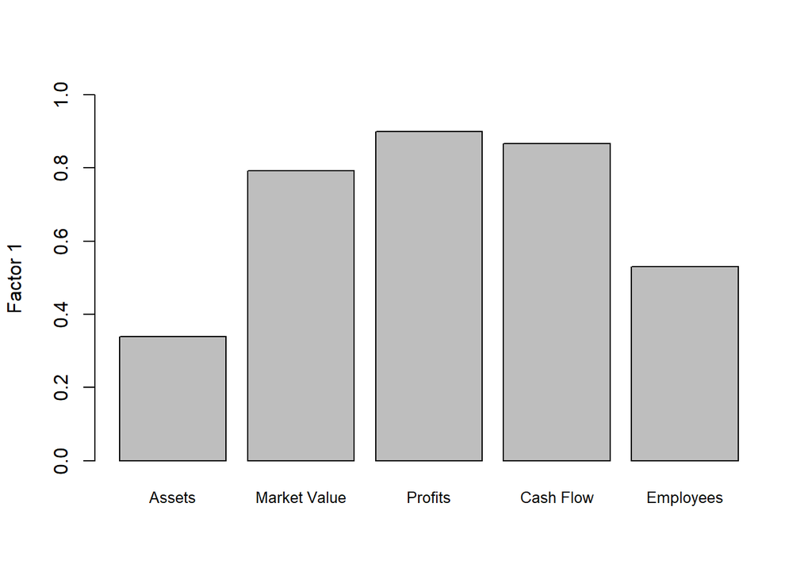

```r
barplot(abs(loadings[,1]),  ylim = c(0,1), ylab = "Factor 1", cex.names = 0.8)
```

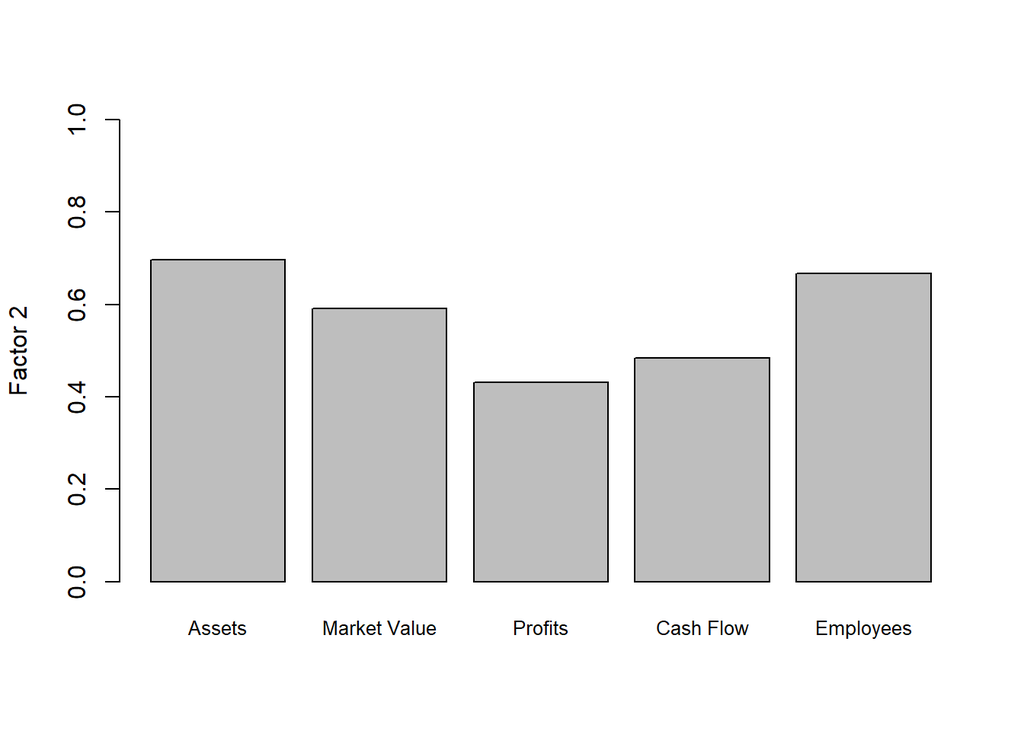

```r
barplot(abs(loadings[,2]),  ylim = c(0,1), ylab = "Factor 2", cex.names = 0.8)
```

Once again, we can see how the variables are separated into two groups.

```r
colnames(uscomp) <- c("Assets","Sales","MarketValue","Profits","CashFlow","Employees","Sector")

uscomp_fit = uscomp[,c(1,3,4,5,6)]
uscomp_fit=scale(uscomp_fit)
uscomp_fit <- as.data.frame(uscomp_fit)
```

We transform slightly the dataset by renaming the columns’ names and by centering and scaling the numerical variables.

```r
#model <- ' economy  =~ MarketValue + Profits + CashFlow
#              structure =~ Assets + Employees'
#fit <- cfa(model, data=uscomp_fit)
#summary(fit, fit.measures=TRUE)
#graph_sem((fit))
```